# Estimación Bayesiana: Primeros pasos con Brms Stan

Hector Najera

21/04/2023

# Introducción

Esta nota presenta los pasos iniciales para hacer estimaciones Bayesianas en **R-Software** usando **STAN** (Hamiltonian Monte Carlo). Lo primero que tenemos que hacer es instalar la paquetería necesaria.

## Instalación de Stan

1 Ir al siguiente sitio y seguir los pasos: https://github.com/stan-dev/rstan/wiki/RStan-Getting-Started

1.1 Noten que seguramente tendran que instalar **Rtools**: https://github.com/stan-dev/rstan/wiki/Configuring-C---Toolchain-for-Windows

# Modelos

## Datos

```r
set.seed(9999)
library(MASS)
data <- data.frame(mvrnorm(n = 50,
                 mu = c(0.5, 0, 10),
                 Sigma = matrix(c(1, 0.7, 0.2,
                                  0.7, 1, 0.1,
                                  0.2, 0.1, 1),
                                nrow = 3)))
head(data)
```

```
##            X1          X2        X3
## 1 -1.02876811 -0.78084976 10.522728
## 2  0.15186388 -1.03098263  9.312037
## 3  0.05494678 -0.78162025 10.652196
## 4  1.17793506  0.72376732 10.265009
## 5 -1.99133093 -3.51602893 10.845105
## 6 -0.21870562 -0.07611094  7.561815
```

Para ver la relación entre los datos hacemos una gráfica simple con la función `plot()`.

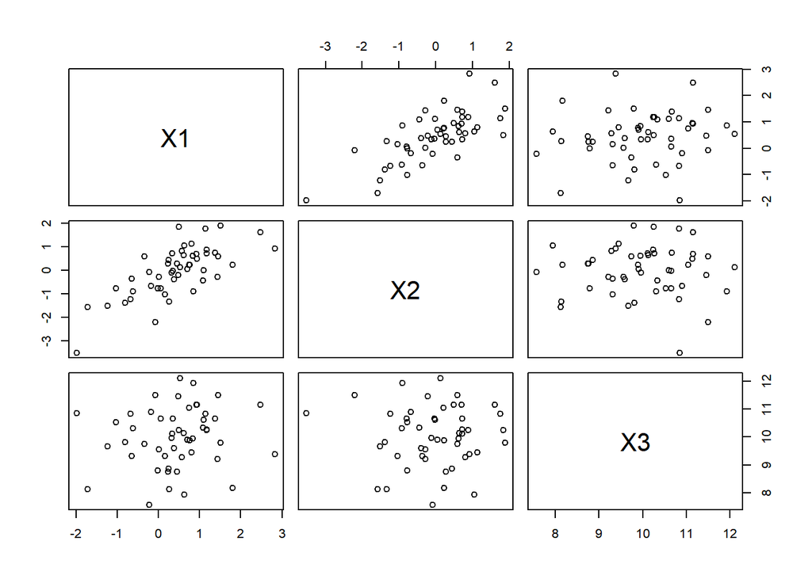

```r
plot(data)
```

Nota: Si no existiera Bayes podríamos estimar un modelo lineal con la función `lm()`. Usamos `summary()` para sintetizar nuestros resultados. Pero esto no nos interesa!

## Modelo lineal OLS

```r
summary(lm(X1~1+X2+X3, data=data))
```

```
##
## Call:
## lm(formula = X1 ~ 1 + X2 + X3, data = data)
##
## Residuals:
##      Min       1Q   Median       3Q      Max
## -1.16945 -0.31493 -0.08673  0.23841  1.87372
##
## Coefficients:
##             Estimate Std. Error t value Pr(>|t|)
## (Intercept) -0.83033    0.87347  -0.951    0.347
## X2           0.64321    0.08725   7.372 2.23e-09 ***
## X3           0.12808    0.08688   1.474    0.147
## ---
## Signif. codes:  0 '***' 0.001 '**' 0.01 '*' 0.05 '.' 0.1 ' ' 1
##
## Residual standard error: 0.6439 on 47 degrees of freedom
## Multiple R-squared:  0.5441, Adjusted R-squared:  0.5247
## F-statistic: 28.04 on 2 and 47 DF,  p-value: 9.634e-09
```

## El paquete BRMS

Primero veremos que pasa con los priors débiles.

```r
library(brms)
library(bayesplot)
library(tidybayes)
library(ggplot2)
library(dplyr)

fit.brms<-brm(X1~ 1 + X2 + X3, family="gaussian",
              prior = c(set_prior("normal(0,100)", class = "b"),
                                      set_prior("normal(0,100)", class="Intercept"),
                                      set_prior("normal(0,10)", class="sigma")),
                            data=data, chains=4, cores=4, iter=1000,  threads = threading(14, grainsize = 100),backend = "cmdstanr")
```

[output not shown]

## Revisando la calidad de las cadenas: dos maneras `plot()` y con `bayesplot`

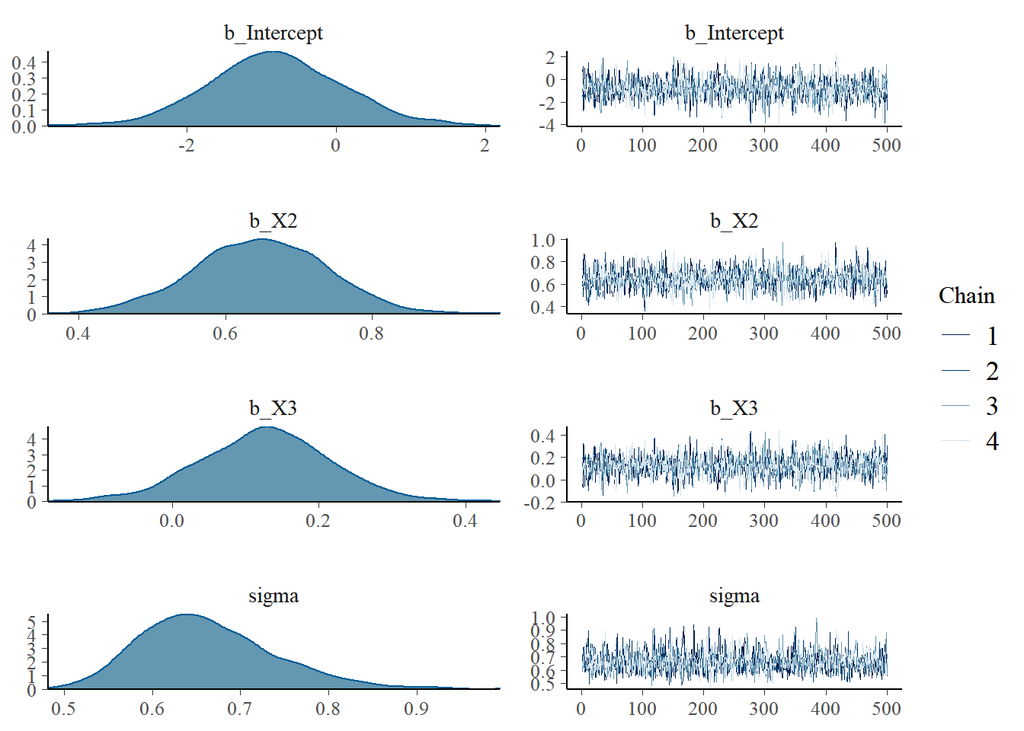

```r
plot(fit.brms)
```

Ahora con bayes plot usamos la función `mcmc_trace`

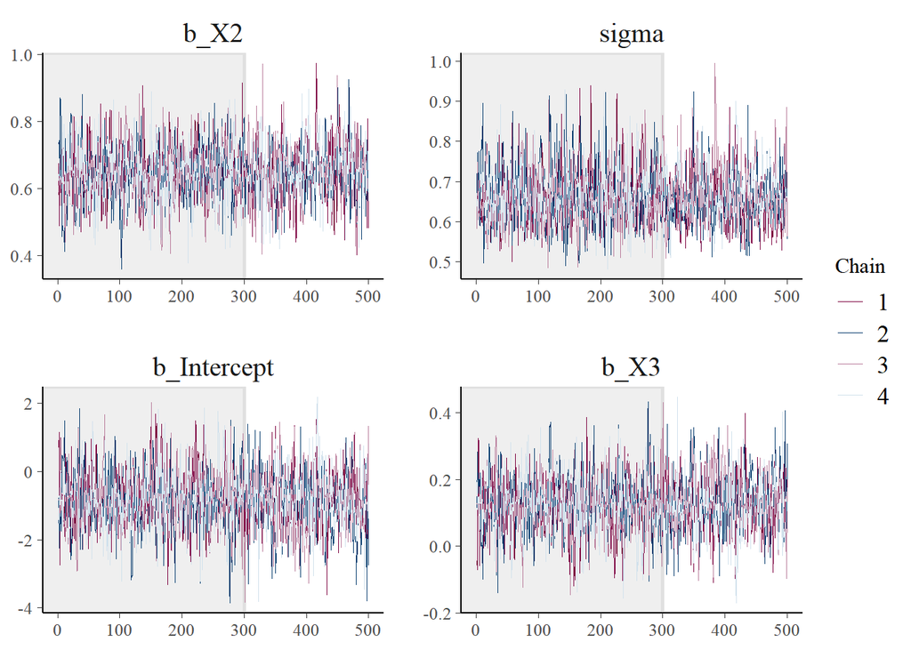

```r
plot_title <- ggtitle("Posterior distributions",
                      "with medians and 95% intervals")

color_scheme_set("mix-blue-pink")
p <- mcmc_trace(fit.brms,  pars = c("b_X2", "sigma",  "b_Intercept", "b_X3"), n_warmup = 300,
                facet_args = list(nrow = 2))
p + facet_text(size = 15)
```

Revisando las posteriores de mis dos parámetros de interés

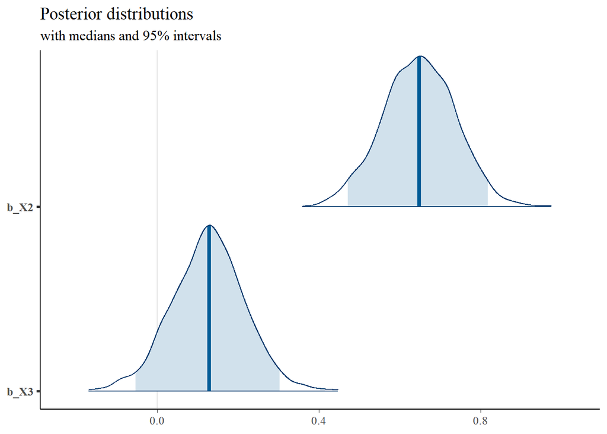

```r
mcmc_areas(fit.brms,
           pars = c("b_X2", "b_X3"),
           prob = 0.95) + plot_title
```

Revisamos R-hat y ESS

```r
fit.brms
```

```
##  Family: gaussian
##   Links: mu = identity; sigma = identity
## Formula: X1 ~ 1 + X2 + X3
##    Data: data (Number of observations: 50)
##   Draws: 4 chains, each with iter = 1000; warmup = 500; thin = 1;
##          total post-warmup draws = 2000
##
## Population-Level Effects:
##           Estimate Est.Error l-95% CI u-95% CI Rhat Bulk_ESS Tail_ESS
## Intercept    -0.82      0.90    -2.56     1.00 1.01     2322     1493
## X2            0.65      0.09     0.47     0.82 1.00     2123     1426
## X3            0.13      0.09    -0.05     0.30 1.01     2362     1505
##
## Family Specific Parameters:
##       Estimate Est.Error l-95% CI u-95% CI Rhat Bulk_ESS Tail_ESS
## sigma     0.66      0.08     0.54     0.83 1.01     1814     1324
##
## Draws were sampled using sample(hmc). For each parameter, Bulk_ESS
## and Tail_ESS are effective sample size measures, and Rhat is the potential
## scale reduction factor on split chains (at convergence, Rhat = 1).
```

### BRMS: Con strong priors

```r
fit2.brms<-brm(X1~ 1 + X2 + X3, family="gaussian",
               prior = c(set_prior("normal(.7,.5)", class = "b", coef="X2"),
                         set_prior("normal(.2,.5)", class = "b", coef="X3"),
                                       set_prior("normal(0,1)", class="Intercept")),
                            data=data, chains=4, cores=4, iter=1000,  threads = threading(14, grainsize = 100),backend = "cmdstanr")
```

[output not shown]

```r
fit2.brms
```

```
##  Family: gaussian
##   Links: mu = identity; sigma = identity
## Formula: X1 ~ 1 + X2 + X3
##    Data: data (Number of observations: 50)
##   Draws: 4 chains, each with iter = 1000; warmup = 500; thin = 1;
##          total post-warmup draws = 2000
##
## Population-Level Effects:
##           Estimate Est.Error l-95% CI u-95% CI Rhat Bulk_ESS Tail_ESS
## Intercept    -0.87      0.87    -2.57     0.80 1.00     1958     1253
## X2            0.65      0.09     0.48     0.82 1.00     2293     1600
## X3            0.13      0.09    -0.04     0.30 1.00     1937     1296
##
## Family Specific Parameters:
##       Estimate Est.Error l-95% CI u-95% CI Rhat Bulk_ESS Tail_ESS
## sigma     0.66      0.07     0.54     0.81 1.00     2066     1427
##
## Draws were sampled using sample(hmc). For each parameter, Bulk_ESS
## and Tail_ESS are effective sample size measures, and Rhat is the potential
## scale reduction factor on split chains (at convergence, Rhat = 1).
```

### Sensibilidad de los resultados a los priors

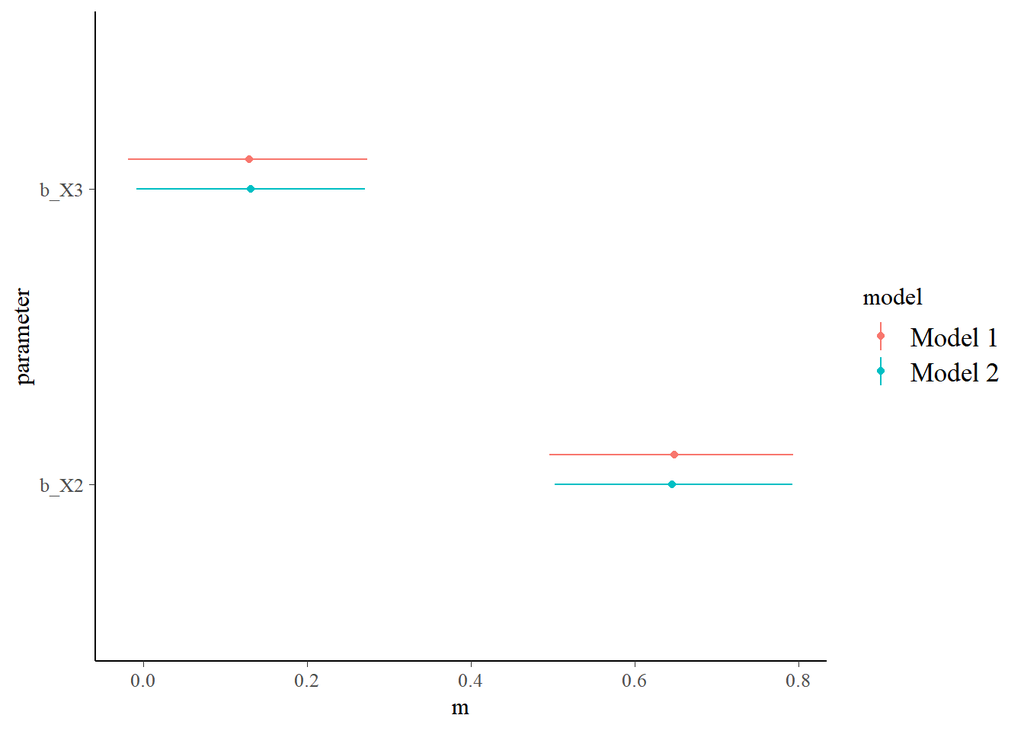

```r
combined <- rbind(mcmc_intervals_data(fit.brms), mcmc_intervals_data(fit2.brms))
combined <- combined[c(2,3,8,9),]
combined$model <- rep(c("Model 1", "Model 2"), each = 2)

# make the plot using ggplot
library(ggplot2)
theme_set(bayesplot::theme_default())
pos <- position_nudge(y = ifelse(combined$model == "Model 2", 0, 0.1))
ggplot(combined, aes(x = m, y = parameter, color = model)) +
  geom_point(position = pos) +
  geom_linerange(aes(xmin = ll, xmax = hh), position = pos)
```

### Prior predictive checks

Una forma de checar si los priors que especificamos tienen sentido es con chequeos predictivos de los a prioris. Esto es, revisar los priors en el contexto de la verosimilitud. Para ello tenemos que incluir la opción `sample_prior="only"`. Después utilizamos `pp_check`. Esta función se utilizá después para evaluar todo el modelo.

```r
fit2.brms.prior<-brm(X1~ 1 + X2 + X3,
                     sample_prior = "only",
                     family="gaussian",
               prior = c(set_prior("normal(.2,.5)", class = "b"),
                                       set_prior("normal(0,1)", class="Intercept")),
                            data=data, chains=4, cores=4, iter=1000,  threads = threading(14, grainsize = 100),backend = "cmdstanr")
```

[output not shown]

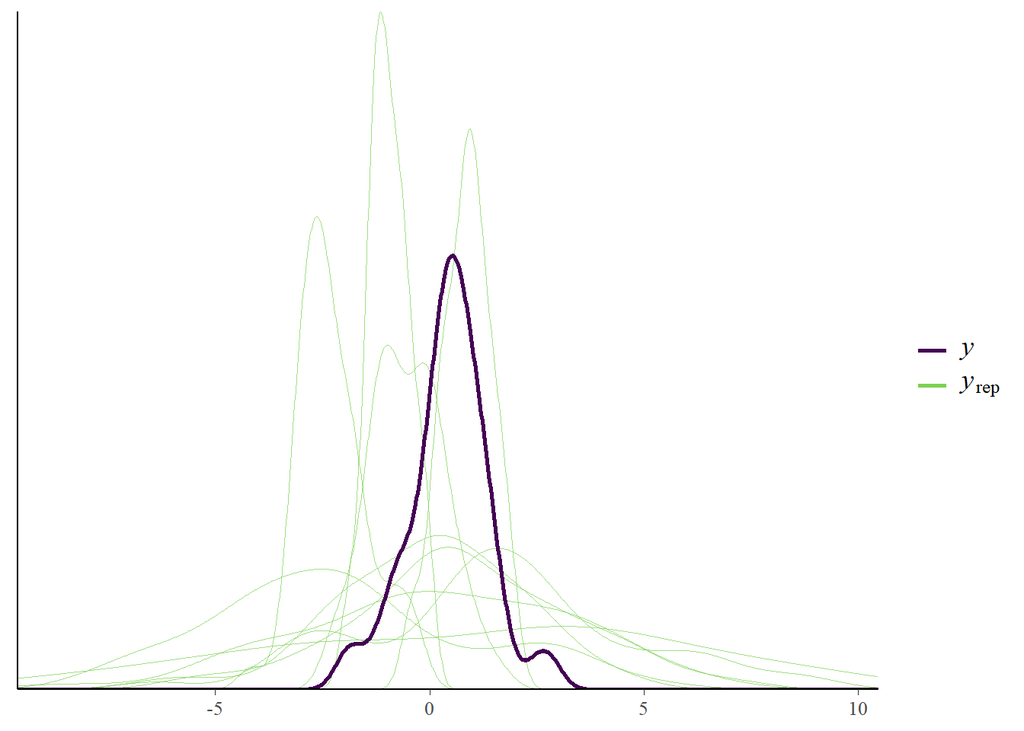

```r
color_scheme_set(scheme = "viridis")
pp_check(fit2.brms.prior)
```

### Posterior predictive checks

Puede mi modelo reproducir la variable dependiente?

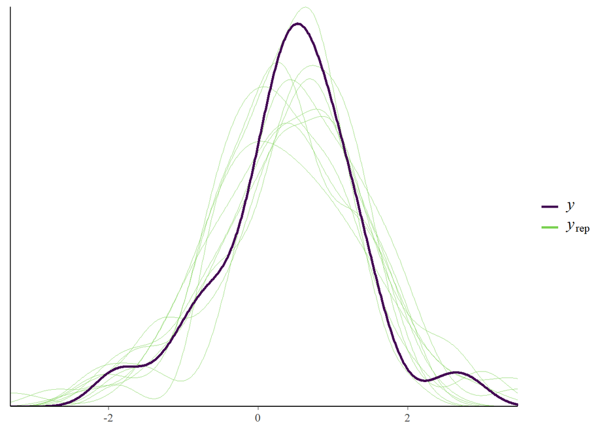

```r
pp_check(fit.brms)
```

Y el otro?

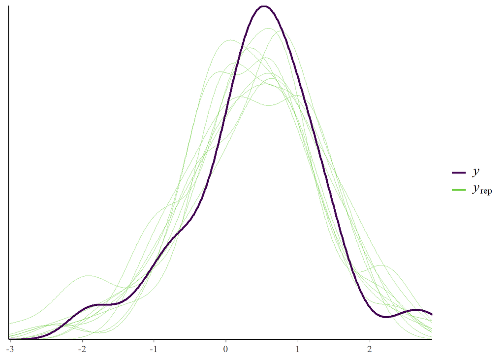

```r
pp_check(fit2.brms)
```

Diagrama de dispersion comparando la predicción

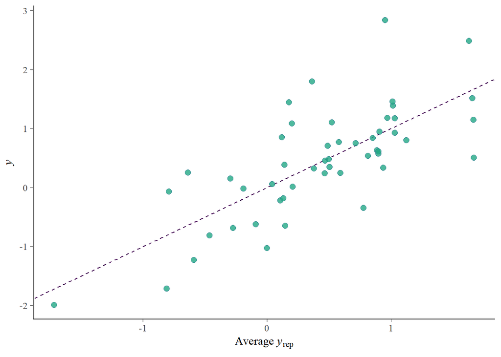

```r
ppc_scatter_avg(y = data$X1, yrep = posterior_predict(fit.brms))
```

Son normales los errores?

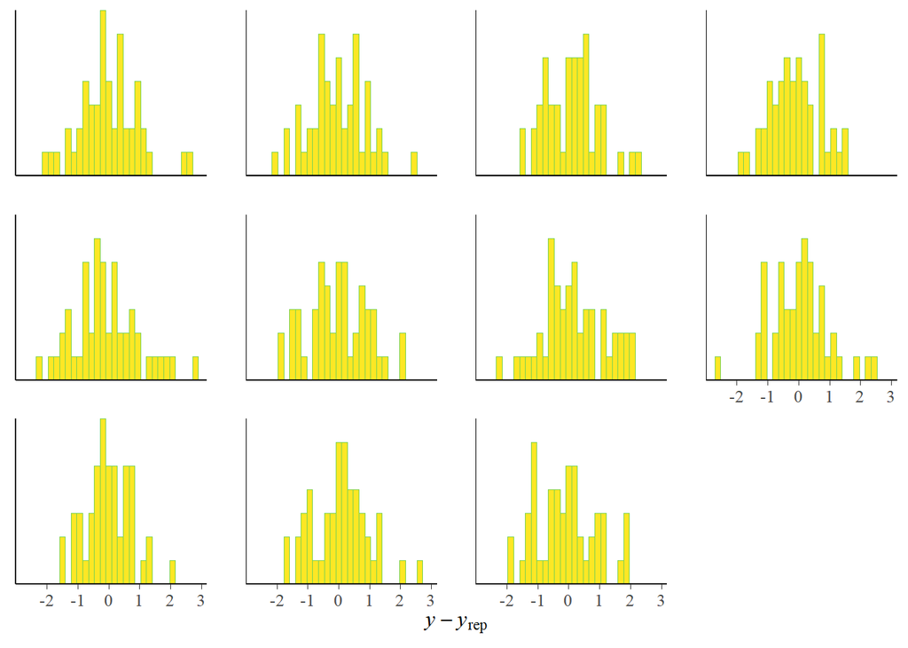

```r
pp_check(fit.brms, type = "error_hist", nsamples = 11)
```

Qué tal si lo que me interesa es reproducir la media? Ah! Esto no sorprende mucho porque el modelo que estimamos está pensado para hacer este trabajo!

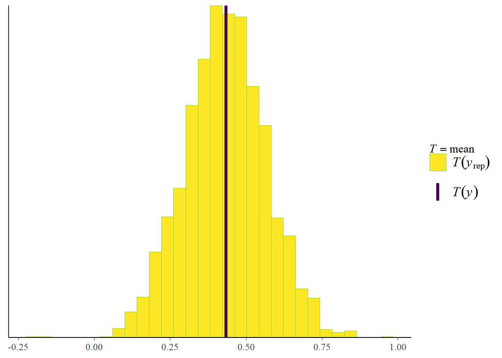

```r
pp_check(fit.brms, type='stat', stat='mean')
```

### Hipótesis

¿Son diferentes los efectos?

```r
hypothesis(fit.brms, "X2 = X3", alpha = 0.01)
```

```
## Hypothesis Tests for class b:
##      Hypothesis Estimate Est.Error CI.Lower CI.Upper Evid.Ratio Post.Prob Star
## 1 (X2)-(X3) = 0     0.52      0.12      0.2     0.85         NA        NA    *
## ---
## 'CI': 98%-CI for one-sided and 99%-CI for two-sided hypotheses.
## '*': For one-sided hypotheses, the posterior probability exceeds 99%;
## for two-sided hypotheses, the value tested against lies outside the 99%-CI.
## Posterior probabilities of point hypotheses assume equal prior probabilities.
```

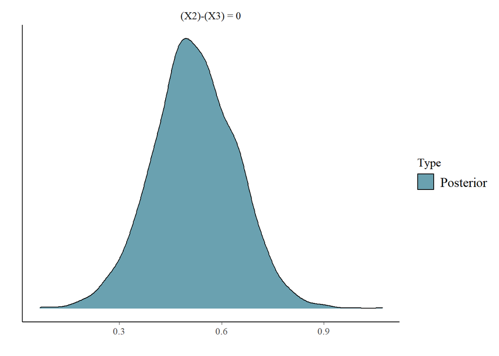

```r
plot(hypothesis(fit.brms, "X2 = X3", alpha = 0.01))
```

```r
hypothesis(fit.brms, "X2 + X3 <.5", alpha = 0.01)
```

```
## Hypothesis Tests for class b:
##         Hypothesis Estimate Est.Error CI.Lower CI.Upper Evid.Ratio Post.Prob
## 1 (X2+X3)-(.5) < 0     0.27      0.13    -0.03     0.59       0.02      0.02
##   Star
## 1
## ---
## 'CI': 98%-CI for one-sided and 99%-CI for two-sided hypotheses.
## '*': For one-sided hypotheses, the posterior probability exceeds 99%;
## for two-sided hypotheses, the value tested against lies outside the 99%-CI.
## Posterior probabilities of point hypotheses assume equal prior probabilities.
```

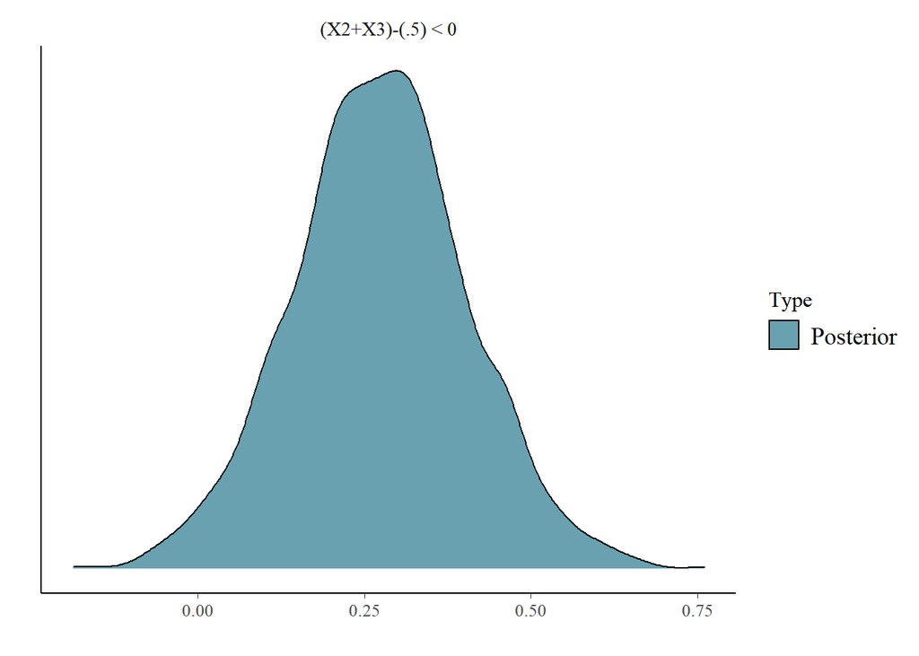

```r
plot(hypothesis(fit.brms, "X2 + X3 <.5", alpha = 0.01))
```

### Predicción

```r
Predict<-predict(fit.brms)
head(Predict)
```

```
##           Estimate Est.Error       Q2.5      Q97.5
## [1,] -0.0008135257 0.6667819 -1.3067198  1.3046902
## [2,] -0.2874182668 0.6931708 -1.7161920  1.0995257
## [3,]  0.0235262985 0.6760731 -1.2764834  1.3013657
## [4,]  0.9596988792 0.6841098 -0.3859255  2.3051510
## [5,] -1.6976085121 0.7342420 -3.1710368 -0.3610779
## [6,]  0.0738883170 0.7114683 -1.2810176  1.4892789
```

```r
Datap<-data.frame(cbind(data$X1,Predict))
head(Datap)
```

```
##            V1      Estimate Est.Error       Q2.5      Q97.5
## 1 -1.02876811 -0.0008135257 0.6667819 -1.3067198  1.3046902
## 2  0.15186388 -0.2874182668 0.6931708 -1.7161920  1.0995257
## 3  0.05494678  0.0235262985 0.6760731 -1.2764834  1.3013657
## 4  1.17793506  0.9596988792 0.6841098 -0.3859255  2.3051510
## 5 -1.99133093 -1.6976085121 0.7342420 -3.1710368 -0.3610779
## 6 -0.21870562  0.0738883170 0.7114683 -1.2810176  1.4892789
```

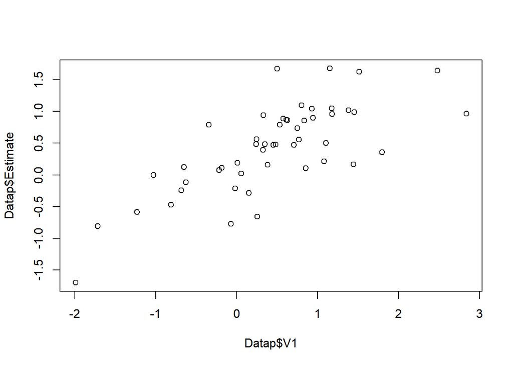

```r
plot(Datap$V1, Datap$Estimate)
```

```r
data2 <- data.frame(mvrnorm(n = 1000,
                 mu = c(0.3, 0, 9),
                 Sigma = matrix(c(1, 0.21, 0.37,
                                  0.21, 1, 0.1,
                                  0.37, 0.1, 1),
                                nrow = 3)))
```

```r
newprediction<-predict(fit.brms, newdata = data2)
head(newprediction)
```

```
##        Estimate Est.Error         Q2.5    Q97.5
## [1,]  1.3440904 0.7039913  0.004482074 2.728608
## [2,] -0.3009917 0.6965880 -1.720188273 1.107641
## [3,]  0.5833521 0.6815561 -0.732731163 1.929697
## [4,]  0.8837233 0.6778165 -0.420096813 2.210315
## [5,]  0.2476796 0.6710130 -1.073810820 1.548102
## [6,] -0.3124313 0.6890323 -1.695866464 1.012494
```

```r
summary(data$y)
```

```
## Length  Class   Mode
##      0   NULL   NULL
```

```r
summary(newprediction[,1])
```

```
##    Min. 1st Qu.  Median    Mean 3rd Qu.    Max.
## -2.0800 -0.1066  0.3088  0.3214  0.7947  2.2692
```